# Capstone Project Week 2 - Project

Robin

6 August 2017

# Week 2 Milestone Report for the Capstone Project

## Introduction

This is the Week 2 Report of the Capstone Project for the Data Science Specialisation. In this report we will try to demonstrate the exploratory analysis we have done trying to understand in the best possible way the nature of the data sets that will be used for creating the prediction algorithm and the final Shiny app. We will show how we downloaded the datasets, how we loaded them into R, we will show some statistics for our data that will be useful in the future creating the prediction algorithm and the final app.

### Download and extract data

We use the [link](https://d396qusza40orc.cloudfront.net/dsscapstone/dataset/Coursera-SwiftKey.zip) provided in the syllabus for the Capstone project to download the Swiftkey zip file containing the data sets, that once extracted, will be used for our project. We then unzip and use only the files from the English database. The English database consists of three separate text files named en_US.blogs.txt, en_US.news.txt and en_US.twitter.txt.

```r
url <- "https://d396qusza40orc.cloudfront.net/dsscapstone/dataset/Coursera-SwiftKey.zip"
if (!file.exists("./Coursera-SwiftKey.zip")) {
    download(url, dest = "./Coursera-SwiftKey.zip", mode = "wb")
}
txtFiles <- unzip("./Coursera-SwiftKey.zip", list = TRUE)
txtFiles <- as.vector(t(sqldf("select Name from txtFiles where Name LIKE ('Cousera-Swiftkey/final/en_US/en%')")))
if (!dir.exists("./Cousera-Swiftkey")) {
    unzip("./Coursera-SwiftKey.zip", files = txtFiles, overwrite = TRUE)
} else {
    for (txtFile in txtFiles) {
        if (!file.exists(txtFile)) {
            unzip("Coursera-SwiftKey.zip", files = txtFile, overwrite = TRUE)
        }
    }
}
```

### After downloading the data sets, we commence to load the files and then assess the sizing.

```r
twitter <- readLines(con <- file("./Coursera-SwiftKey/final/en_US/en_US.twitter.txt",
    encoding = "UTF-8"))
close(con)
blogs <- readLines(con <- file("./Coursera-SwiftKey/final/en_US/en_US.news.txt",
    encoding = "UTF-8"))
close(con)
news <- readLines(con <- file("./Coursera-SwiftKey/final/en_US/en_US.blogs.txt",
    encoding = "UTF-8"))
close(con)
```

```r
#getting the number of lines in the files
twitter_lines <- countLines('./Coursera-SwiftKey/final/en_US/en_US.twitter.txt')
blogs_lines <- countLines('./Coursera-SwiftKey/final/en_US/en_US.news.txt')
news_lines <- countLines('./Coursera-SwiftKey/final/en_US/en_US.blogs.txt')
## Getting the size of the Files
blog_size <- file.info('./Coursera-Swiftkey/final/en_US/en_US.blogs.txt')$size/(1024^2)
news_size <- file.info('./Coursera-Swiftkey/final/en_US/en_US.news.txt')$size/(1024^2)
twitter_size <- file.info('./Coursera-Swiftkey/final/en_US/en_US.twitter.txt')$size/(1024^2)
## Getting the number of words for each file
twitter_Words <- sum(sapply(gregexpr("\\W+", twitter),   length)) + 1
news_Words <- sum(sapply(gregexpr("\\W+", news),   length)) + 1
blogs_Words <- sum(sapply(gregexpr("\\W+", blogs),   length)) + 1
knitr::kable(data.frame(
              files = c("blogs","news","twitter"),
              Size_Mb = c(blog_size,news_size,twitter_size),
              Words = c(blogs_Words,news_Words,twitter_Words),
              Lines(blogs_lines,news_lines,twitter_lines),

  )
)
```

[output not shown]

Due to the big size of our files, that made processing both difficult & time consuming of the calculations on our data sets, we now create three separate sample files, 10000 rows each, one for each text file, in order to create our corpus and wich will enable us to do all the preprocessing and calculations at a more expedient rate.

```r
sampleTwitter <- sample(twitter, 10000, replace = FALSE)
sampleBlogs <- sample(blogs, 10000, replace = FALSE)
sampleNews <- sample(news, 10000, replace = FALSE)
repo <- "./Coursera-Swiftkey/final/en_US/sample"
if (!dir.exists(repo)) {
     dir.create(repo)
}
```

We now commence to create our corpus from the sample files and do all the preprocessing needed to cleanse our data. We name it myCorpus.

```r
con <- file("./en.txt", "rb")
profanity <- readLines(con,skipNul = TRUE, warn = FALSE)
close(con)
repo <- "./Coursera-Swiftkey/final/en_US/sample"
myCorpus <- VCorpus(
                     DirSource(repo, pattern = 'txt', encoding = 'UTF-8'),
                     readerControl = list(language = 'en')
                     )
# Custom function used to remove non ASCII characters.
removeNonASCII <- content_transformer(function(x)
     gsub("[^\x20-\x7E]","", x))
# Custom function used to remove URLs.
removeURLs <- content_transformer(function(x)
     gsub("(f|ht)tp(s?):(\\s*?)//(.*)[.][a-z]+(/?)", "", x))
# Data cleansing and transformations.
myCorpus <- tm_map(myCorpus, removeNonASCII)
myCorpus <- tm_map(myCorpus, content_transformer(tolower))
myCorpus <- tm_map(myCorpus, removeURLs)
myCorpus <- tm_map(myCorpus, removeWords, stopwords("english"))
myCorpus <- tm_map(myCorpus, removeWords, stopwords("SMART"))
myCorpus <- tm_map(myCorpus, removePunctuation)
myCorpus <- tm_map(myCorpus, removeNumbers)
myCorpus <- tm_map(myCorpus, stripWhitespace)
myCorpus <- tm_map(myCorpus, removeWords, profanity)
myCorpus <- tm_map(myCorpus, stemDocument)
#To proceed, we create a document term matrix.This is what we will be using from this point on:
dtm <- DocumentTermMatrix(myCorpus)
dtm
```

```
## <<DocumentTermMatrix (documents: 3, terms: 34942)>>
## Non-/sparse entries: 52033/52793
## Sparsity           : 50%
## Maximal term length: 38
## Weighting          : term frequency (tf)
```

```r
#We refine our document term matrix by removing sparse terms:
dtms <- removeSparseTerms(dtm, 0.1)
dtms
```

```
## <<DocumentTermMatrix (documents: 3, terms: 5421)>>
## Non-/sparse entries: 16263/0
## Sparsity           : 0%
## Maximal term length: 13
## Weighting          : term frequency (tf)
```

## Exploratory analysis

We will organize our terms in order to be useful for the calculations and the plotting that we will do. At first we organize all the terms in the dtms by frequency in descending order:

```r
freq <- sort(colSums(as.matrix(dtms)), decreasing = TRUE)
```

The ten most frequent words are:

```r
head(freq,10)
```

```
##  time  year   day  make peopl  work  love  good  back thing
##  2229  2221  1782  1706  1475  1402  1357  1316  1191  1049
```

The ten least frequent words are:

```r
tail(freq,10)
```

```
##      tam    troll   turnip  unhappi     waco    waltz   watkin      zen
##        3        3        3        3        3        3        3        3
## zeppelin     zing
##        3        3
```

We can find the associations (terms that correlate) of the most or least frequent words using the findAssocs() function. For example, the correlated terms, with a correlation percentage 0.99, for the word “love” are the following:

```r
findAssocs(dtms,"love",corlimit = 0.99)
```

```
## $love
##      check    cheddar     cooler    disgust      funni     hilari
##       1.00       1.00       1.00       1.00       1.00       1.00
##    hipster     hungri      hurri      insan        ipa       jade
##       1.00       1.00       1.00       1.00       1.00       1.00
##        mac    mustach       mute       nice    penguin      readi
##       1.00       1.00       1.00       1.00       1.00       1.00
##       rubi       rude      shirt       sick       sigh       song
##       1.00       1.00       1.00       1.00       1.00       1.00
## soundtrack     stupid       till      upset        vip       wait
##       1.00       1.00       1.00       1.00       1.00       1.00
##      watch       wish       amaz     asleep   birthday        cam
##       1.00       1.00       0.99       0.99       0.99       0.99
##      crave       cute      excit     facial     forgot       hell
##       0.99       0.99       0.99       0.99       0.99       0.99
##        lip        mad       morn      panic       rain     skinni
##       0.99       0.99       0.99       0.99       0.99       0.99
##      tooth       ugli    weekend       yell     youtub
##       0.99       0.99       0.99       0.99       0.99
```

## Plotting

We plot the word frequencies from our data:

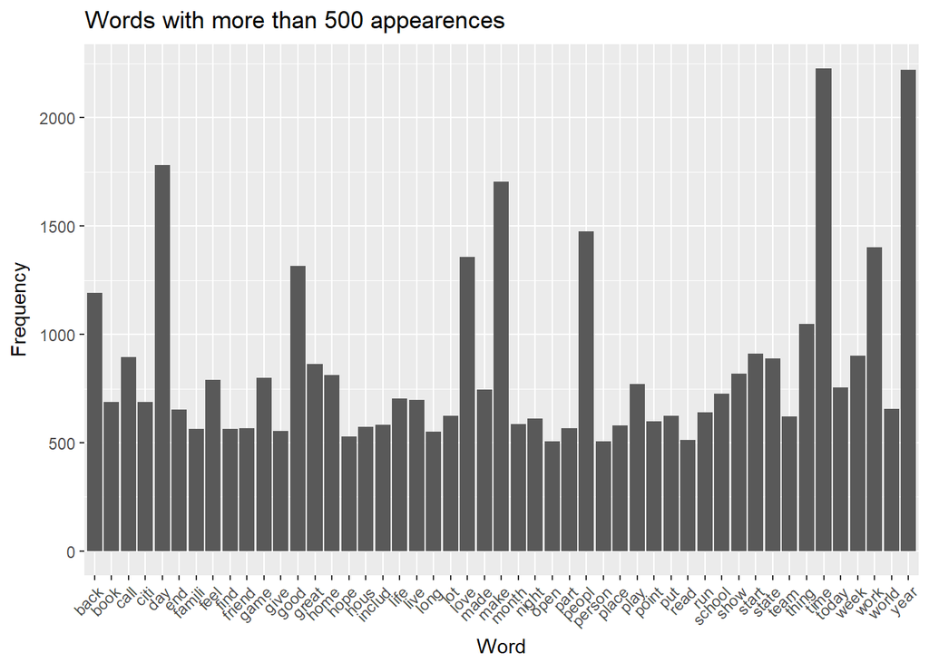

```r
df <- data.frame(word = names(freq),freq = freq)
p <- ggplot(subset(df, freq > 500), aes(word, freq))
p <- p + geom_bar(stat = "identity")
p <- p + theme(axis.text.x = element_text(angle = 45, hjust = 1))
p <- p + xlab("Word")
p <- p + ylab("Frequency")
p <- p + ggtitle("Words with more than 500 appearences")
p
```

We then use the wordcloud package to re-inspect the most frequent words from our corpus.

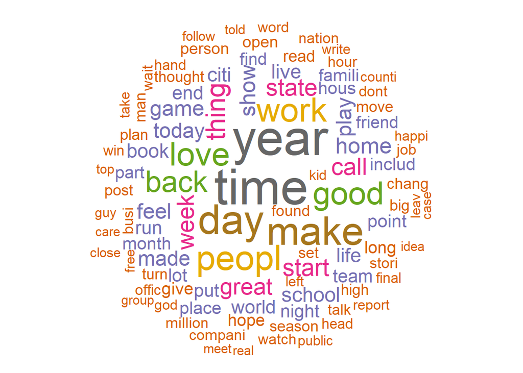

```r
set.seed(12345)
pal <- brewer.pal(8,"Dark2")
tmp <- data.frame(word = names(freq), freq = freq)
row.names(tmp) <- NULL
tmp <- head(tmp,100)
wordcloud(words = tmp$word,freq = tmp$freq,random.order = FALSE, colors = pal)
```

We can clearly see that there are certain words like year, time or love that leap out at us indicating they are repeated many times in our corpus as previously confirmed in prior steps.

## Tokenization

```r
require(RWeka)
```

```r
# require(rJava) tokenizer functions
unigram <- function(x) NGramTokenizer(x, Weka_control(min = 1, max = 1))
bigram <- function(x) NGramTokenizer(x, Weka_control(min = 2, max = 2))
trigram <- function(x) NGramTokenizer(x, Weka_control(min = 3, max = 3))
## n-grams frequency function
FreqEvaluation <- function(tdm) {
    freq <- sort(rowSums(as.matrix(tdm)), decreasing = TRUE)
    return(data.frame(word = names(freq), freq = freq))
}
## frequency plotting function
makePlot <- function(data, label) {
    ggplot(data[1:50, ], aes(reorder(word, -freq), freq)) + labs(x = label,
        y = "Frequency") + theme(axis.text.x = element_text(angle = 60, size = 12,
        hjust = 1)) + geom_bar(stat = "identity", fill = I("grey50"))
}
```

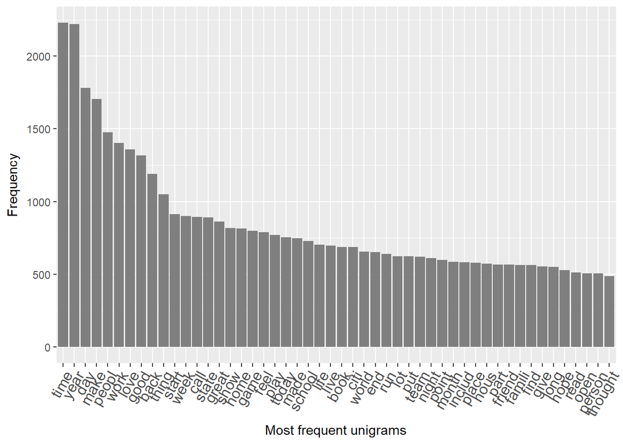

```r
require(RWeka)
freqUnigrams <- FreqEvaluation(removeSparseTerms(TermDocumentMatrix(myCorpus, contro = list(tokenize = unigram)), 0.99))
makePlot(freqUnigrams, "Most frequent unigrams")
```

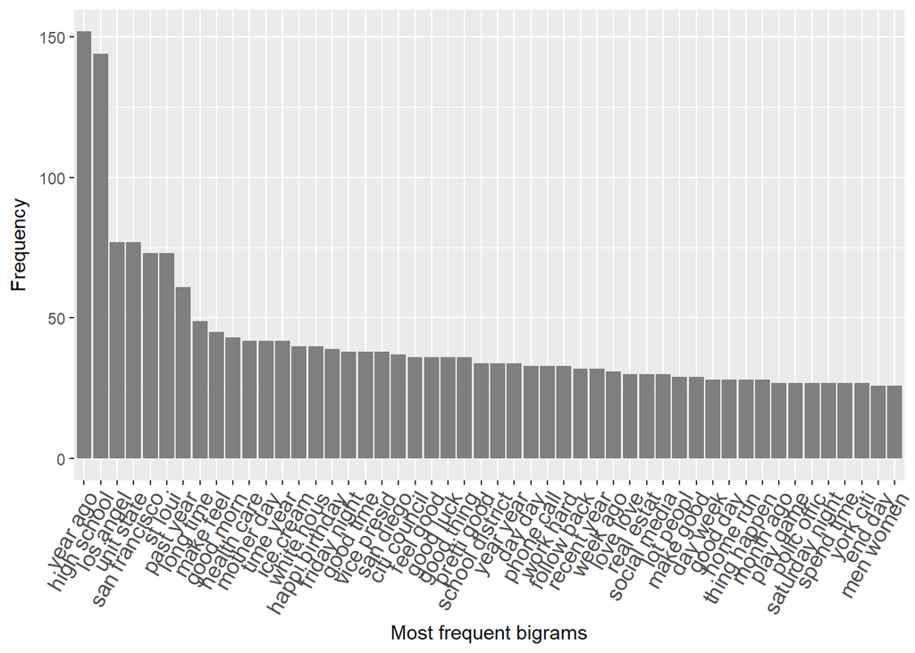

```r
require(RWeka)
freqBigrams <- FreqEvaluation(removeSparseTerms(TermDocumentMatrix(myCorpus, control = list(tokenize = bigram)), 0.999))
makePlot(freqBigrams, "Most frequent bigrams")
```

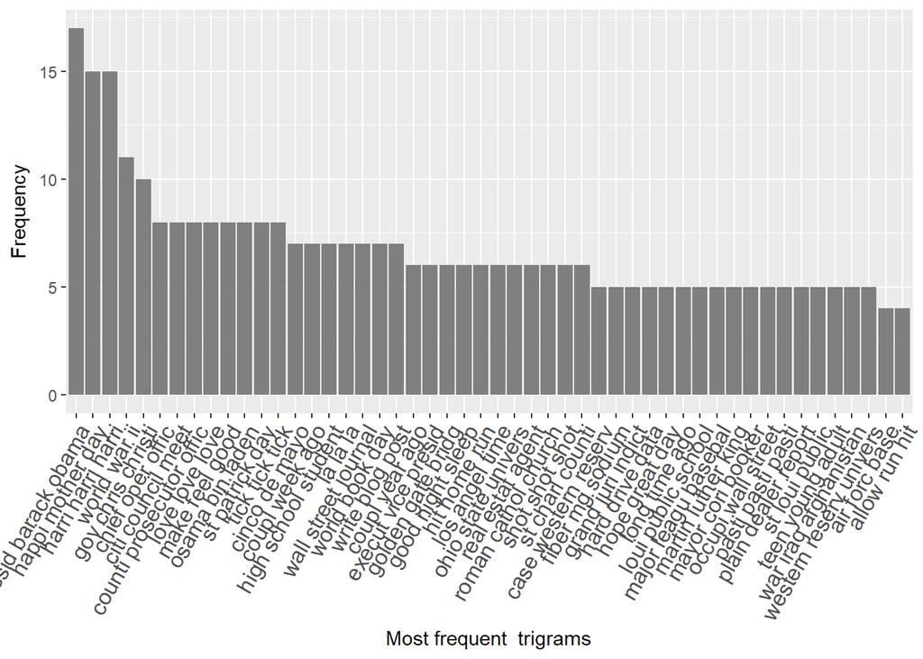

```r
require(RWeka)
freqTrigrams <- FreqEvaluation(removeSparseTerms(TermDocumentMatrix(myCorpus, control = list(tokenize = trigram)), 0.9999))
makePlot(freqTrigrams, "Most frequent  trigrams")
```